# Demonstracja użycia pakietu `energydemandforecaster`

(c) WLOG Solutions

2014-02-05

# 1 Wstęp

Niniejszy dokument opisuje przykładowe użycie modułu generowania prognoz [zapotrzebowania na energię (KSE)](http://www.pse.pl/index.php?dzid=77).

# 2 Przygotowanie środowiska pracy

## 2.1 Pakiety

### 2.1.1 Pakiety wymagane przez pakiet `energydemandforecaster`

Będziemy potrzebowali następujących pakietów:

- `data.table`
- `lubridate`
- `EnergyDataRepository`
- `redrepoadapter`
- `weatherforecaster`
- `energydemandforecaster`

Pakiety ładujemy poniższymi instrukcjami

```r
library(data.table)
library(lubridate)
library(EnergyDataRepository)
library(edrepoadapter)
library(weatherforecaster)
library(energydemandforecaster)
```

### 2.1.2 Dodatkowe pakiety

Na potrzeby niniejszej prezentacji możliwości będziemy potrzebowali następujących pakietów.

- `ggplot2`
- `plyr`
- `reshape2`

Pakiety ładujemy następującymi instrukcjami:

```r
library(ggplot2)
library(plyr)
library(reshape2)
```

## 2.2 Repozytorium danych energetycznych

Aby przykłady z niniejszej prezentacji zadziałały potrzebujemy aby w naszym repozytorium były odpowiednie dane:

- [Zapotrzebowanie energetyczne kraju (KSE)](http://www.pse.pl/index.php?dzid=77)
- [Dane pogodowe](http://polish.wunderground.com/)

Poniższy kod pokazuje w jaki sposób powinniśmy zaktualizować nasze repozytorium.

```r
edrepo <- edrepo.buildEnv(edrepo.path)
edrepo.uploadData(
    names = c("ZAP_KSE"),
    from = "2002-01-01",
    till = "2013-12-31",
    env = edrepo)

edrepo.uploadData(
    name = "Pogodowe",
    from = "2002-01-01",
    till = "2013-12-31",
    env = edrepo)
```

**Uwaga**

> Aktualizacja repozytorium jest wymagana tylko i wyłącznie jeśli nie posiadamy w repozytorium odpowiednich danych.

**Uwaga**

> Na potrzeby całej prezentacji zakładamy, że repozytorium znajduje się podkatalogu `edrepo` w aktualnym katalogu roboczym. W ogólnym przypadku repozytorium może być w dowolnym miejscu.

# 3 Budowanie modelu

Poniżej opisujemy, krok po kroku, jak zbudować model prognostyczny dla zapotrzebowania na energię elekryczną. Budowa modelu składa się z następujących kroków:

1. Przygotowanie danych
2. Zbudowanie modelu

## 3.1 Przygotowanie danych

Aby zbudować model należy dostarczyć dwie tabele danych:

1. `holidays` - jest to ramka danych o jednej kolumnie o nazwie data zawierająca daty (w formacie `POSIXct`) świąt.
2. `train.data` - jest to ramka danych o zawierająca następujące informacje:
   - Temperatura [stopnie Celsjusza]
   - Historia zapotrzebowania energetycznego kraju

### 3.1.1 Produkt krajowy brutto

Dane o produkcie krajowym brutto są elementem pakietu `edrepoadapter` i mamy do nich dostęp poprzez funkcję `data`. Po pobraniu danych dokonujemy ich przetworzenia do odpowiedniego formatu.

```r
data(polish_gdp, package="edrepoadapter")
polish_gdp <- data.table(polish_gdp)
polish_gdp[, quarter := as.character(quarter)]
```

Struktura danych zawierających informację o produkcie krajowym brutto:

```r
str(polish_gdp)
```

```
Classes 'data.table' and 'data.frame':  42 obs. of  3 variables:
 $ year   : int  2003 2003 2003 2003 2004 2004 2004 2004 2005 2005 ...
 $ quarter: chr  "Q1" "Q2" "Q3" "Q4" ...
 $ gdp    : num  2.2 3.8 4.7 4.7 7 6.1 4.8 4.9 2.1 2.8 ...
 - attr(*, ".internal.selfref")=<externalptr>
```

Próbka danych o produkcie krajowym brutto:

| year | quarter | gdp |
| --- | --- | --- |
| 2003 | Q1 | 2.2 |
| 2003 | Q2 | 3.8 |
| 2003 | Q3 | 4.7 |
| 2003 | Q4 | 4.7 |
| 2004 | Q1 | 7 |
| 2004 | Q2 | 6.1 |
| 2012 | Q1 | 3.5 |
| 2012 | Q2 | 2.4 |
| 2012 | Q3 | 2 |
| 2012 | Q4 | 1.1 |
| 2013 | Q1 | 0.5 |
| 2013 | Q2 | 0.8 |

### 3.1.2 Święta

Dane o świętach są elementem pakietu `edrepoadapter` i mamy do nich dostęp poprzez funkcję `data`. Po pobraniu danych dokonujemy ich przetworzenia do odpowiedniego formatu.

```r
data(polish_holidays, package="edrepoadapter")
polish_holidays <- data.table(polish_holidays)
polish_holidays[, date := as.Date(as.character(date))]
```

```r
str(polish_holidays)
```

```
Classes 'data.table' and 'data.frame':  190 obs. of  1 variable:
 $ date: Date, format: "2002-03-31" "2003-04-20" ...
 - attr(*, ".internal.selfref")=<externalptr>
```

Próbka dat dla świąt:

| date |
| --- |
| 2002-03-31 |
| 2003-04-20 |
| 2004-04-11 |
| 2005-03-27 |
| 2006-04-16 |
| 2007-04-08 |

### 3.1.3 Dane z repozytorium

Najpierw musimy podłączyć się do repozytorium. Robimy to poniższą instrukcją.

```r
edrepo <- edrepo.buildEnv(edrepo.path)
```

Z repozytorium będziemy potrzebowali następujących danych:

- Dane o zapotrzebowaniu energetycznym kraju - trzymane w tabeli `ZAP_KSE`.
- Dane o pogodzie - trzymane w tabeli `Pogodowe`.

Możemy sprawdzić z jakiego okresu mamy dostępne dane o zapotrzebowaniu energetycznym kraju

```r
edrepo.getInfo(edrepo, names="ZAP_KSE")$ZAP_KSE
```

```
$source
[1] "PSE"

$columns
[1] "Data"    "Godzina" "Minuty"  "Wolumen"

$dataRange
$dataRange$from
[1] "2002-01-01"

$dataRange$till
[1] "2014-01-28"
```

Zatem dane o zapotrzebowaniu energetycznym kraju są dostępne w okresie od 2002-01-01 do 2014-01-28.

W przypadku danych o pogodzie mamy w repozytorium następujące dane

```r
edrepo.getInfo(edrepo, names="Pogodowe")$Pogodowe
```

```
$source
[1] "Pogodowe"

$columns
 [1] "Data"                             "TemperaturaMaksymalnaC"
 [3] "TemperaturaSredniaC"              "TemperaturaMinimalnaC"
 [5] "PunktRosyC"                       "MeanDewPointC"
 [7] "MinDewpointC"                     "MaxWilgotnosc"
 [9] "MeanWilgotnosc"                   "Min.Wilgotnosc"
[11] "Max.CisnienieNaPoziomieMorzahPa"  "Mean.CisnienieNaPoziomieMorzahPa"
[13] "MinCisnienieNaPoziomieMorzahPa"   "MaxWidzialnoscKm"
[15] "MeanWidzialnoscKm"                "MinWidzialnoscKm"
[17] "MaxPredkoscWiatruKmH"             "MeanPredkoscWiatruKmH"
[19] "MaxPredkoscWPorywieKmH"           "Opadymm"
[21] "CloudCover"                       "Wydarzenia"
[23] "WindDirDegrees"                   "Miasto"
[25] "DataWstawieniaDoBazy"

$dataRange
$dataRange$from
[1] "2001-12-31"

$dataRange$till
[1] "2014-01-12"
```

Zatem dane meteorologiczne dostępne są w okresie od 2001-12-31 do 2014-01-12.

**Uwaga**

> Surowe dane w repozytorium nie są w formacie, który jest wymagany przez funkcję `demand.model`. Dlatego te dane należy odpowiednio przetworzyć. Można to robić ręcznie lub skorzystać z funkcji `demand.prepare.input.data` z pakietu `edrepoadapter`.

Przygotowujemy dane wejściowe dla funkcji `demand.model` tworzącej model prognostyczny

```r
demand.input.data <- demand.prepare.input.data(
    gdp = polish_gdp,
    holidays = polish_holidays,
    edrepo = edrepo)
str(demand.input.data)
```

```
List of 2
 $ train.data:Classes 'data.table' and 'data.frame':    104784 obs. of  5 variables:
  ..$ date       : Date[1:104784], format: "2002-01-01" ...
  ..$ hour       : num [1:104784] 0 1 2 3 4 5 6 7 8 9 ...
  ..$ temperature: num [1:104784] -5.12 -5.12 -5.12 -5.12 -5.12 ...
  ..$ gdp        : num [1:104784] NA NA NA NA NA NA NA NA NA NA ...
  ..$ demand     : num [1:104784] 15414 14825 14411 14450 14360 ...
  ..- attr(*, ".internal.selfref")=<externalptr>
  ..- attr(*, "sorted")= chr [1:2] "date" "hour"
 $ holidays  :Classes 'data.table' and 'data.frame':    190 obs. of  1 variable:
  ..$ date: Date[1:190], format: "2002-03-31" ...
  ..- attr(*, ".internal.selfref")=<externalptr>
```

**Uwaga**

> Funkcja `demand.prepare.input.data` wygenerowała *ostrzeżenie* (`warning`), mówiące o tym, że były braki w danych temperaturowych. Braki te zostały wypełnione zgodnie z modelem błądzenia losowego (*weź ostatnią znaną wartość*).

Próbka danych treningowych do budowy modelu prognostycznego zapotrzebowania energetycznego kraju

| date | hour | temperature | gdp | demand |
| --- | --- | --- | --- | --- |
| 2002-01-01 | 0 | -5.125 |  | 15414 |
| 2002-01-01 | 1 | -5.125 |  | 14825 |
| 2002-01-01 | 2 | -5.125 |  | 14411 |
| 2002-01-01 | 3 | -5.125 |  | 14450 |
| 2002-01-01 | 4 | -5.125 |  | 14360 |
| 2002-01-01 | 5 | -5.125 |  | 14163 |
| 2014-01-12 | 18 | 3 |  | 19411 |
| 2014-01-12 | 19 | 3 |  | 19483 |
| 2014-01-12 | 20 | 3 |  | 18934 |
| 2014-01-12 | 21 | 3 |  | 17994 |
| 2014-01-12 | 22 | 3 |  | 17091 |
| 2014-01-12 | 23 | 3 |  | 15851 |

Poniżej prezentujemy wykres (uśrednionych do doby) danych treningowych

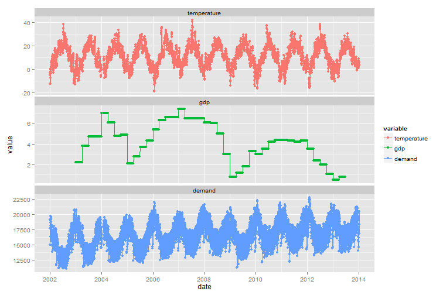

```r
print(
    ggplot(
        melt(
            demand.input.data$train.data[,
                                         list(
                                             temperature = mean(temperature),
                                             gdp = mean(gdp),
                                             demand = mean(demand)),
                                         by = date],
            id.vars = "date"),
        aes(x=date, y=value, colour=variable)) +
    geom_line() +
    geom_point() +
    facet_wrap(~ variable, nrow=3, ncol = 1, scales = "free_y"))
```

## 3.2 Budowa modelu

Aby zbudować model należy skorzystać z funkcji `demand.model` z pakiety `energydemandforecaster`. Zacznijmy od przeczytania dokumentacji dla tej funkcji

```r
help(demand.model)
```

Zbudujmy model poniższą instrukcją:

```r
model <- demand.model(
    train.data = demand.input.data$train.data[ date < as.Date("2013-01-01"),],
    holidays = demand.input.data$holidays)
```

**Uwaga**

> Model zbudowaliśmy dla okrojonego zestawu danych treningowych poprzez wyrzucenie całego roku 2013. Zrobiliśmy to aby pokazać jak efektywny jest nasz model prognostyczny.

## 3.3 Diagnostyka

Model jest obiektem typu `list` z dodanym atrybutem `class` informującym, że jest to model zapotrzebowania energetycznego kraju.

```r
names(model)
```

```
[1] "daily.model"    "daily.profiles"
```

```r
class(model)
```

```
[1] "demand.model"
```

Jak widać model składa się z dwóch komponentów:

- `daily.model` - model prognostyczny dla średnio-dobowego zapotrzebowanai energetycznego kraju.
- `daily.profiles` - profile dla poszczególnych typów dni tygodni.

### 3.3.1 Profile dla typów dni tygodnia

Zobaczmy jak wyglądają profile dla poszczególnych dni tygodni dla różnych miesięcy:

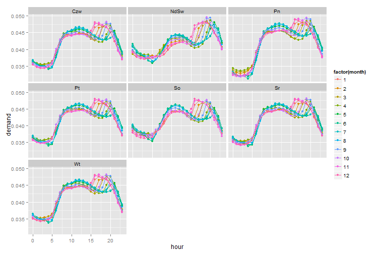

```r
print(
    ggplot(model$daily.profiles,
           aes(x = hour, y = demand, color = factor(month))) +
    geom_point() +
    geom_line() +
    facet_wrap(~ day.type))
```

Zobaczmy jak wyglądają profile dla poszczególnych dni tygodni w ramach każdego miesiąca:

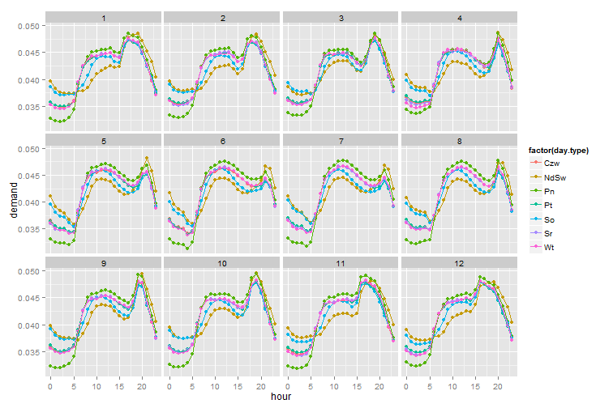

```r
print(
    ggplot(model$daily.profiles,
           aes(x = hour, y = demand, color = factor(day.type))) +
    geom_point() +
    geom_line() +
    facet_wrap(~ month))
```

### 3.3.2 Model dla średnio-dobowego zapotrzebowania

Podsumowanie modelu `daily.model`

Fitting linear model: demand ~ .

|  | Estimate | Std. Error | t value | Pr(>\|t\|) |
| --- | --- | --- | --- | --- |
| **temperature** | -19.95 | 1.773 | -11.25 | 6.997e-29 |
| **gdp** | 51.7 | 5.592 | 9.244 | 3.984e-20 |
| **t** | 0.2054 | 0.01184 | 17.36 | 8.04e-65 |
| **lag_1** | 0.6042 | 0.0104 | 58.1 | 0 |
| **lag_7** | 0.07381 | 0.00966 | 7.641 | 2.761e-14 |
| **mdM1_NdSw** | -2319 | 118.5 | -19.58 | 4.103e-81 |
| **mdM1_Pn** | 1770 | 123.6 | 14.32 | 3.134e-45 |
| **mdM1_Pt** | -128.4 | 119.1 | -1.077 | 0.2813 |
| **mdM1_So** | -1499 | 119.8 | -12.52 | 3.325e-35 |
| **mdM1_Sr** | 143.4 | 119.1 | 1.204 | 0.2288 |
| **mdM1_Wt** | 415.8 | 118.5 | 3.508 | 0.0004566 |
| **mdM10_Czw** | -328.6 | 117.9 | -2.786 | 0.005358 |
| **mdM10_NdSw** | -2668 | 125.8 | -21.21 | 4.38e-94 |
| **mdM10_Pn** | 1208 | 126 | 9.592 | 1.584e-21 |
| **mdM10_Pt** | -441.4 | 116.6 | -3.785 | 0.0001564 |
| **mdM10_So** | -1955 | 119.2 | -16.4 | 2.632e-58 |
| **mdM10_Sr** | -301.6 | 117.4 | -2.569 | 0.01023 |
| **mdM10_Wt** | 18.07 | 118.7 | 0.1523 | 0.879 |
| **mdM11_Czw** | -142.1 | 117.8 | -1.206 | 0.2278 |
| **mdM11_NdSw** | -2767 | 117.4 | -23.56 | 3.861e-114 |
| **mdM11_Pn** | 1569 | 125.2 | 12.53 | 2.948e-35 |
| **mdM11_Pt** | -291.3 | 117.2 | -2.486 | 0.01296 |
| **mdM11_So** | -1611 | 120.1 | -13.42 | 4.488e-40 |
| **mdM11_Sr** | 61.46 | 117.2 | 0.5243 | 0.6001 |
| **mdM11_Wt** | 187.6 | 117.6 | 1.594 | 0.1109 |
| **mdM12_Czw** | -195.3 | 115.8 | -1.686 | 0.09185 |
| **mdM12_NdSw** | -2465 | 112.9 | -21.84 | 2.906e-99 |
| **mdM12_Pn** | 1279 | 123.2 | 10.39 | 6.537e-25 |
| **mdM12_Pt** | -451.9 | 116.4 | -3.883 | 0.0001049 |
| **mdM12_So** | -1701 | 117.1 | -14.53 | 1.736e-46 |

[output cut: 59 more lines]

Wykres autokorelacji reszt modelu `daily.model`

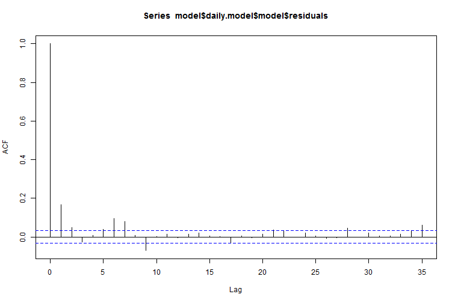

Wykres częściowej autokorelacji reszt modelu `daily.model`

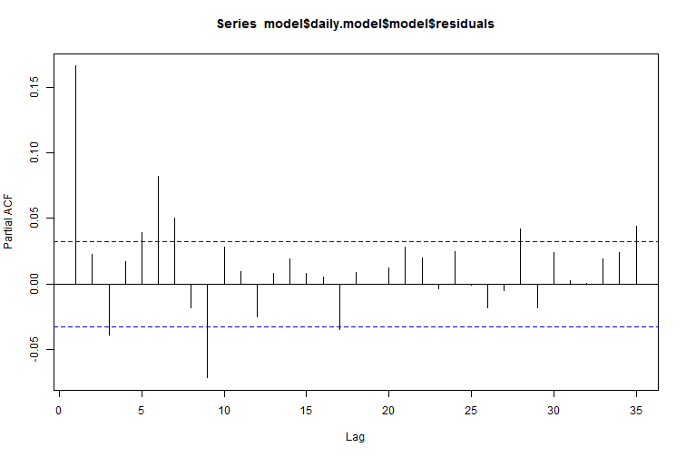

# 4 Generowanie prognoz

W tej części pokażemy jak mając model prognostyczny zapotrzebowania energetycznego kraju można generować prognozy. Generowanie prognoz składa się z następujacych kroków:

1. Ustalenie jaki horyzont prognozy nas interesuje.
2. Przygotowanie prognoz predyktorów: temperatury oraz produktu krajowego brutto.
3. Wygenerowanie prognozy.

## 4.1 Horyzont prognozy

Zdefiniujmy horyzont prognozy na 366 dni.

```r
n.ahead <- 366
```

## 4.2 Przygotowanie prognoz predyktorów

### 4.2.1 Generowanie prognozy temperatury

Prognozę temperatury wykonamy przy wykorzystaniu pakietu `weatherforecaster`. Pakiet ten dostarcza funkcje `temperature.model`, która tworzy model prognostyczny dla temperatury. Korzystając z tej funkcji wygenerujemy prognozę

```r
temp.pred <- predict(
    temperature.model(history = demand.input.data$train.data[date < as.Date("2013-01-01"), list(date, temperature)]),
    start.date = as.Date("2013-01-01"),
    n.ahead = n.ahead)
```

Próbka zawartości ramki danych `temp.pred`

| date | temperature.pred |
| --- | --- |
| 2013-01-01 | 0.4877 |
| 2013-01-02 | 1.88 |
| 2013-01-03 | 0.6512 |
| 2013-01-04 | 0.2113 |
| 2013-01-05 | -0.6642 |
| 2013-01-06 | 0.4535 |
| 2013-12-27 | 0.7168 |
| 2013-12-28 | 0.2064 |
| 2013-12-29 | 0.333 |
| 2013-12-30 | 0.411 |
| 2013-12-31 | 0.6265 |
| 2014-01-01 | 0.4877 |

Wykres prognozy pogody

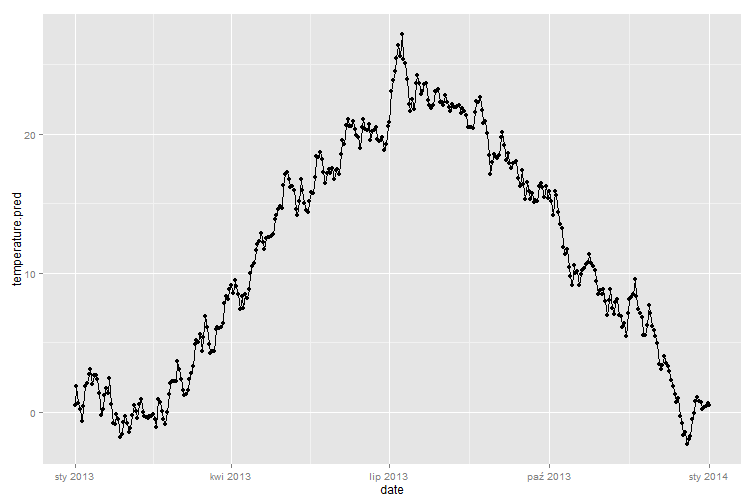

```r
print(
    ggplot(
        temp.pred,
        aes(x=date,
            y=temperature.pred)) +
    geom_point() +
    geom_line())
```

### 4.2.2 Prognoza produktu krajowego brutto

Przyjmiemy, że produkt krajowy brutto będzie wynosił stałą wartość równą 3,3.

## 4.3 Prognoza zapotrzebowania

Mamy już wszystkie elementy potrzebne do wykonania prognozy zapotrzebowania energetycznego kraju. Prognozę tę generujemy jak poniżej

```r
demand.pred <- predict(
    model,
    n.ahead = n.ahead,
    xregs = data.frame(
        temperature = temp.pred$temperature.pred,
        gdp = gdp.pred),
    holidays = demand.input.data$holidays)
setkeyv(demand.pred, c("date", "hour"))
```

Porównajmy prognozę z rzeczywistym wykonaniem

```r
setkeyv(demand.input.data$train.data, c("date", "hour"))
demand.comp <- demand.input.data$train.data[date >= as.Date("2013-01-01"), ][demand.pred][, list(date, hour, demand, demand.pred)][, list(demand=mean(demand), demand.pred=mean(demand.pred)), by=date]
```

```r
print(class(demand.pred$date))
```

```
[1] "Date"
```

```r
print(class(demand.input.data$train.data$date))
```

```
[1] "Date"
```

| date | demand | demand.pred |
| --- | --- | --- |
| 2013-01-01 | 14687 | 15718 |
| 2013-01-02 | 18739 | 17690 |
| 2013-01-03 | 19860 | 18864 |
| 2013-01-04 | 19951 | 19504 |
| 2013-01-05 | 18150 | 18499 |
| 2013-01-06 | 16265 | 16823 |
| 2013-01-07 | 20061 | 19874 |
| 2013-01-08 | 20855 | 20447 |
| 2013-01-09 | 20699 | 20654 |
| 2013-01-10 | 20783 | 20716 |
| 2013-01-11 | 20605 | 20694 |
| 2013-01-12 | 18905 | 19223 |
| 2013-01-13 | 17334 | 17390 |
| 2013-01-14 | 20821 | 20603 |
| 2013-01-15 | 21153 | 21254 |
| 2013-01-16 | 21242 | 21421 |
| 2013-01-17 | 21342 | 21375 |
| 2013-01-18 | 21312 | 21197 |
| 2013-01-19 | 19294 | 19600 |
| 2013-01-20 | 17497 | 17688 |
| 2013-01-21 | 20874 | 20838 |
| 2013-01-22 | 21435 | 21472 |
| 2013-01-23 | 21528 | 21623 |
| 2013-01-24 | 21457 | 21568 |
| 2013-01-25 | 21411 | 21379 |
| 2013-01-26 | 19360 | 19785 |
| 2013-01-27 | 17699 | 17886 |
| 2013-01-28 | 20710 | 21056 |
| 2013-01-29 | 20645 | 21647 |
| 2013-01-30 | 20421 | 21734 |
| 2013-01-31 | 20069 | 21650 |
| 2013-02-01 | 20045 | 21329 |
| 2013-02-02 | 17993 | 19468 |
| 2013-02-03 | 16365 | 17634 |
| 2013-02-04 | 19769 | 20608 |
| 2013-02-05 | 20163 | 21064 |
| 2013-02-06 | 20220 | 21096 |
| 2013-02-07 | 20392 | 21093 |
| 2013-02-08 | 20299 | 20944 |
| 2013-02-09 | 18432 | 19190 |
| 2013-02-10 | 16746 | 17451 |
| 2013-02-11 | 19998 | 20483 |
| 2013-02-12 | 20488 | 20956 |
| 2013-02-13 | 20448 | 20982 |
| 2013-02-14 | 20509 | 21002 |
| 2013-02-15 | 20203 | 20883 |
| 2013-02-16 | 18312 | 19145 |
| 2013-02-17 | 16734 | 17426 |

Wykres pokazujący prognozę oraz rzeczywiste wykonanie

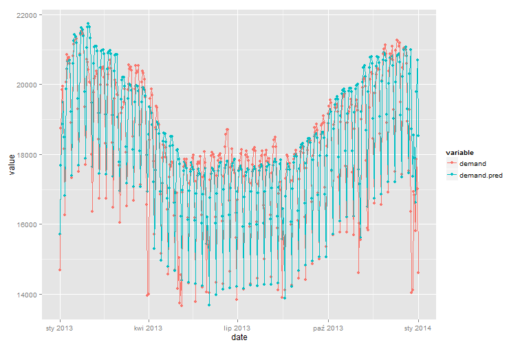

```r
print(
    ggplot(
        melt(demand.comp,
             id.vars = "date"),
        aes(x=date, y=value, col=variable)) +
    geom_point() +
    geom_line())
```

Przybliżenie na okres, dla którego posiadamy dane o rzeczywistym wykonaniu

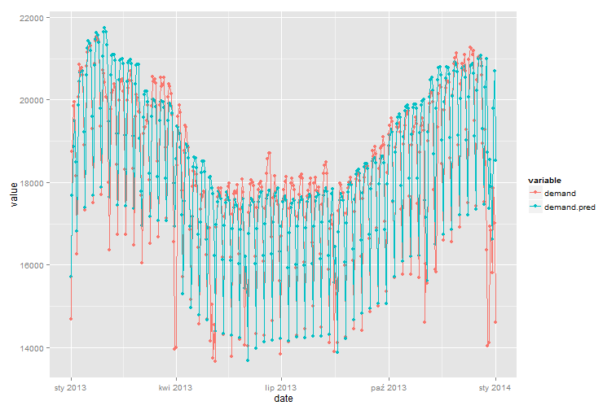

```r
print(
    ggplot(
        melt(demand.comp[complete.cases(demand.comp), ],
             id.vars = "date"),
        aes(x=date, y=value, col=variable)) +
    geom_point() +
    geom_line())
```

Dane rzeczywiste mamy w zakresie od 2013-01-01 do 2014-01-01. Błąd modelu ([MAPE - średni bezwzględny błąd procentowy](http://en.wikipedia.org/wiki/Mean_absolute_percentage_error)) dla średnio-dobowego zapotrzebowania na energię dla tego okresu wyniósł **3,02%**.

Na koniec wyeksportujemy wynik prognozy do pliku `CSV`

```r
write.table(
    x = demand.comp[
        complete.cases(demand.comp),
        ":="(
            timestamp = ymd_h(sprintf("%s %d", date, hour)),
            error.MWh = demand - demand.pred,
            error.pct = (demand - demand.pred)/demand)],
    file = "demand_pred.csv",
    sep = ";",
    dec = ",",
    row.names = FALSE,
    col.names = TRUE)
```